# Informe práctico 1

VISCAINO, Lucas Esteban

La base datos desagregados obtenidos en la Encuesta de turismo Emisivo sobre el flujo de los residentes de Uruguay que viajan fuera del país y el gasto de los mismos según destino principal del viaje entre diciembre de 2016 y marzo de 2024. Esta base de datos se encuentra disponible en el [Catálogo de datos abiertos](https://catalogodatos.gub.uy/dataset/1c1d75d0-b3c9-4ea4-a519-8c6b1468e589/resource/922f23e1-296c-490a-a3df-61e03e122d17#) de Uruguay.

## Parte 1

**Pregunta:** ¿Existe una relación entre los gastos totales del viaje con el nivel de estudio del encuestado? ¿Se mantiene esa relación (si existe) cuando tenemos en cuenta el destino al que viajan?

### Introducción

**Conjunto de Datos** El conjunto de datos desagregados suministrado nos provee diversas variables que son de utilidad a la hora de realizar una exploración del turismo en Uruguay ya que podemos evaluar lugar de salida, destino, gastos, periodos de los viajes, etc., siendo un dataset robusto para su análisis.

**Enfoque del informe** Para esta sección del informe, los datos de más utilidad resultarán los de gastos totales, ya provisto dentro del dataset, así como también los niveles de estudio de los encuestados y los destinos. En el caso de estos últimos dos datos, es probable que haya que realizar cierta manipulación en caso de toparnos con valores nulos.

### Enfoque

**Exploración de los datos** Resultó importante poder explorar previamente los datos de las variables a utilizar, particularmente el nivel de estudio, ya que hubo varias instancias de datos faltantes que afectaban directamente la confección de los gráficos e interpretación de los mismos.

**Elaboración de los gráficos** Considero que un gráfico de dona es ideal para un primer acercamiento a la exploración de la pregunta, ya que podemos ver de manera clara la diferencia de gastos totales realizadas por cada grupo de Nivel de Estudio. Luego, para poder hacer un análisis más en profundidad, se puede usar un gráfico de barras separado en facetas y así visualizar qué patrones de gasto hay en cada Destino y si efectivamente se corresponden también con el Nivel de Estudios.

### Análisis

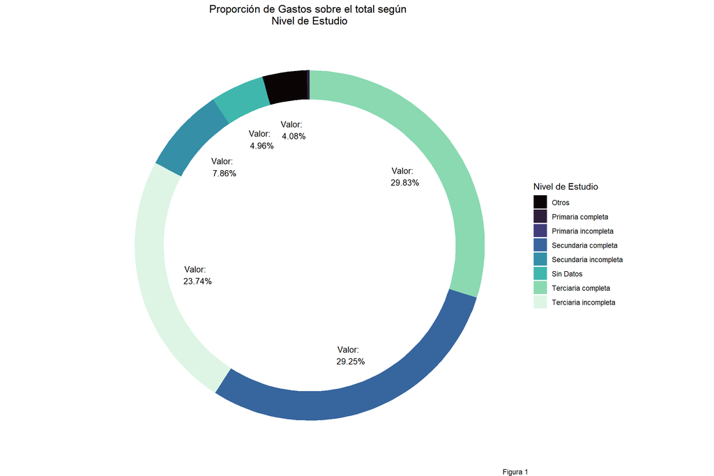

```r
## hacer este paso me sirvio para ver los datos NA y darme cuenta que puedo calificarlos como Sin Datos para que el grafico quede bien ordenado
estudio_exp<-arrange(turistas_raw|>
                     group_by(id_nivel_estudio,estudio)|>
                       summarise(
                         estudio_count = n()
                       ))
## cambio los valores de NA por Sin Datos/0, ordenar el dataset y calculo porcentual p/pareto
usd_tot <- sum(turistas_raw$gasto_total)
turistas_adj <- turistas_raw|> mutate (
  estudio = ifelse(is.na(estudio),"Sin Datos",estudio),
  id_nivel_estudio = ifelse(is.na(id_nivel_estudio),0,id_nivel_estudio)
  )|>
  group_by(id_nivel_estudio,estudio)|>
  summarise(sum_gasto = sum(gasto_total))|> mutate(
    gasto_perc = sum_gasto/usd_tot
    )
turistas_adj <- arrange(turistas_adj,desc(gasto_perc))

turistas_adj$perc_acc <- cumsum(turistas_adj$gasto_perc)

#primer grafico - donut chart
# Create donut data.
donut_data <- turistas_adj

# Compute percentages
donut_data$fraction <- turistas_adj$gasto_perc

# Compute the cumulative percentages (top of each rectangle)
donut_data$ymax <- turistas_adj$perc_acc

# Compute the bottom of each rectangle
donut_data$ymin <- c(0, head(donut_data$ymax, n=-1))

# Compute label position
donut_data$labelPosition <- (donut_data$ymax + donut_data$ymin) / 2

# Label the sections
donut_data$label <- paste0("Valor: \n ", scales::percent(donut_data$gasto_perc))

# Make the plot
donut<-ggplot(donut_data, aes(ymax=ymax, ymin=ymin, xmax=4, xmin=3, fill=estudio)) +
  geom_rect() +
  geom_text( x=2, aes(y=labelPosition, label=label), size=3.5,check_overlap=TRUE,show.legend = FALSE) +
  scale_fill_viridis(option="mako",discrete=TRUE)+
  coord_polar(theta="y") +
  xlim(c(-2, 4)) +
  theme_void() +
  theme(
    plot.title=element_text(hjust=0.5)
    )+
  labs(title="Proporción de Gastos sobre el total según \n Nivel de Estudio ",fill="Nivel de Estudio",caption="Figura 1")


donut
```

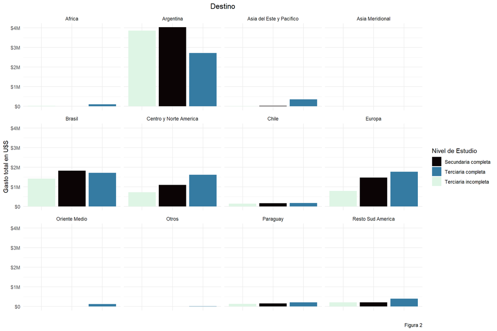

```r
#genero un df nuevo incluyendo los destinos
#filtro los datos para incluir solo los gastos de los 3 grupos mayoritarios que se aprecian en el grafico de dona
turistas_adj_dest <- turistas_raw|> mutate (
  estudio = ifelse(is.na(estudio),"Sin Datos",estudio),
  id_nivel_estudio = ifelse(is.na(id_nivel_estudio),0,id_nivel_estudio))|>
  group_by(id_nivel_estudio,estudio,destino)|>
  summarise(sum_gasto = sum(gasto_total))
turistas_adj_dest <- turistas_adj_dest|> filter(id_nivel_estudio >= 4 & id_nivel_estudio != 7)
#segundo grafico
plot <- turistas_adj_dest |>
ggplot (aes(x = fct_reorder(estudio,sum_gasto), y = sum_gasto,fill=estudio))+
  geom_col()+
  theme_minimal()+
  scale_fill_viridis(option="mako",discrete=TRUE)+
    theme(
    legend.position="right",
    axis.text.x=element_blank(),
    plot.title=element_text(hjust=0.5),
    )+
  scale_x_discrete(guide = guide_axis(n.dodge = 2)) +
  scale_y_continuous(labels = label_currency(scale_cut = cut_short_scale() )) +
  labs(title="Destino",x="",y="Gasto total en U$S",fill="Nivel de Estudio",caption="Figura 2")
plot + facet_wrap(~destino)
```

### Discusión

**Relaciones entre variables**  
De la figura 1 podemos apreciar claramente que hay una relación entre el nivel de estudios y los gastos totales de los viajes. De hecho, la mayoría de los gastos totales de todos los encuestados (~83%) fueron realizados por los individuos agrupados en niveles de estudio de secundaria completa en adelante. Los encuestados con un nivel de estudios menor (secundaria incompleta o menor) no realizan viajes costosos analizándolos como grupo. Los grupos que no presentan nivel de estudios declarado (Otros o Sin datos) tampoco realizan, en acumulado, viajes costosos.  
En cuanto a la relación con el destino, se puede apreciar de la figura 2 que hay una cierta relación entre el nivel de estudio y los gastos totales, pero no se cumple para todos los destinos. Particularmente, Argentina y Brasil son dos destinos para los cuales el nivel de estudios más alto (Terciaria Completa) no representa la categoría con el gasto total mayor. Sin embargo, para el resto de los destinos la relación se mantiene.  
**Comentarios adicionales** Sería interesante explorar los datos a través de un gráfico de violín, para tener más variables dentro de la visualización y poder ver así, por ejemplo, la dispersión de los datos en cada categoría. Personalmente, considero que aún me falta práctica en R para poder lograr visualizaciones más avanzadas e interesantes.

## Parte 2

**Pregunta:** ¿Se podrá vincular algún motivo particular (ej.: Tratamiento de Salud) con un destino? ¿Habrá una estacionalidad (mes del año) asociada también?

### Introducción

**Conjunto de Datos** En este caso, del conjunto de datos nos resulta interesante el destino así como también el motivo por el cual viajan los encuestados. Asimismo, la fecha de salida nos ayudará a evaluar si efectivamente hay una estacionalidad dentro del conjunto y para qué tipo de viaje o destino en particular.

**Enfoque del informe** El enfoque de esta segunda parte será la exploración de frecuencias de tipo de viaje según destino, así como también su comportamiento a través del tiempo.

### Enfoque

**Exploración de los datos** Creo que resultaría interesante para explorar los datos de la primera pregunta realizar un gráfico de tipo mapa de calor para ver si efectivamente hay destinos con tipos de viaje que se destaquen por sobre el resto. Luego, para su asociación con la fecha de salida, el tipo de gráfico puede ser variado, pero considero que un gráfico que muestre áreas apiladas resultaría interesante para visualizar los datos y evaluar si hay una estacionalidad asociada al destino y tipo de viaje. Así, los gráficos ideales para responder esta pregunta son el heatmap para la primera pregunta, y de columnas apiladas para la segunda.

**Elaboración de los gráficos**  
Los gráficos de esta sección fueron más complejos de elaborar ya que no había previamente trabajado con heatmaps o series temporales. Si bien R tiene su función base para heatmaps (heatmap()), geom_tile() de ggplot2 resultó más fácil de manipular para obtener un resultado estéticamente más atractivo, asi como también resultó más sencillo de incluir las leyendas del gráfico en sí.  
En cuanto al segundo gráfico, mi primer intento fue con geom_col() pero tuve problemas al popular el gráfico debido a cómo había manipulado los datos de fecha. Por otro lado, probé utilizando geom_area() pero generó gráficos con overplotting, por lo que volví a mi elección inicial de usar una visualización con columnas apiladas. La manipulación de fechas en esta etapa fue difícil, pero me pareció importante mantener la granularidad de los meses para poder entender la estacionalidad de los diferentes motivos de viaje.

### Análisis

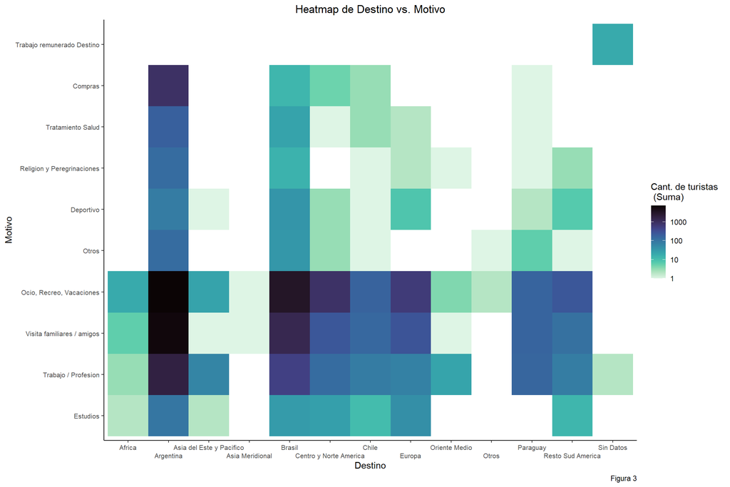

```r
motivo_exp<-arrange(turistas_raw|>
                     group_by(id_motivo,motivo)|>
                       summarise(
                         motivo_count = n()
                       ))
#no hay datos faltantes (N/A)
destino_exp<-arrange(turistas_raw|>
                     group_by(id_destino,destino)|>
                       summarise(
                         destino_count = n()
                       ))
#no hay datos faltantes (N/A)
#procedo con la elaboración de los gráficos sin ajustar la base de datos
tur_hm <- turistas_raw|>
  group_by(destino,motivo)|>count(motivo)|>summarise(N=sum(n))|>mutate(
  motivo=ifelse(motivo=="MICE","Otros",motivo),
  motivo=fct_reorder(motivo,N))


plot_hm<-ggplot(tur_hm,aes(x=destino,y=,motivo,fill=N))+
  geom_tile()+
  scale_x_discrete(guide = guide_axis(n.dodge = 2))+
  scale_fill_viridis(option="mako",direction=-1,transform="log10")+
  theme_classic()+
  theme(legend.position="right",
        axis.text.x=element_text(size=8),
        axis.text.y=element_text(size=8),
        plot.title=element_text(hjust=0.5))+
  labs(title="Heatmap de Destino vs. Motivo",x="Destino",y="Motivo",fill="Cant. de turistas \n (Suma)",caption="Figura 3")
plot_hm
```

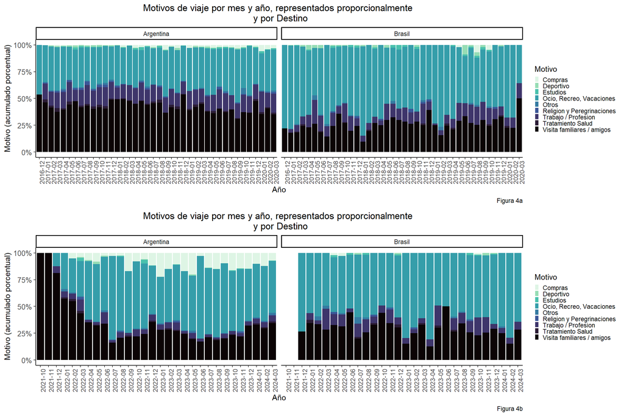

```r
# teniendo en cuenta que los destinos más visitados son argentina y brasil, propongo evaluar la estacionalidad de ambas regiones
tur_est <- turistas_raw |> filter(destino == "Argentina" | destino == "Brasil")
tur_est <- tur_est |> mutate(fecha_salida = ymd(fecha_salida),year = format_ISO8601(fecha_salida, precision = "y"),month = format_ISO8601(fecha_salida, precision ="ym", format = "%b-%y"),motivo=ifelse(motivo=="MICE","Otros",motivo))|>
  group_by(year,month,destino,motivo)|>count(month,motivo)|>summarise(mot_N=sum(n))
tur_est_20 <- tur_est|>filter(year <= 2020)
tur_est_24 <- tur_est|>filter(year>2020)
p_area_20 <- ggplot(tur_est_20,aes(x=month,y=mot_N,fill=motivo))+
  #geom_area(position="fill")+
  geom_col(position="fill")+
  scale_fill_viridis(option="mako",discrete = TRUE,direction=-1)+
  theme_classic()+
  #scale_x_discrete(guide = guide_axis(n.dodge = 2))+
  #scale_x_date(date_breaks = "year", date_labels="%Y",
  #             date_minor_breaks = "months")+
  scale_y_continuous(labels=scales::percent)+
  theme(legend.position="right",
        legend.key.size = unit(0.5,"char"),
        axis.text.x=element_text(size=9,angle=90),
        axis.text.y=element_text(size=10),
        plot.title=element_text(hjust=0.5))+
  labs(title="Motivos de viaje por mes y año, representados proporcionalmente \n y por Destino",x="Año",y="Motivo (acumulado porcentual)",fill="Motivo",caption="Figura 4a")+ facet_wrap(~destino)

p_area_24 <- ggplot(tur_est_24,aes(x=month,y=mot_N,fill=motivo))+
  #geom_area(position="fill")+
  geom_col(position="fill")+
  scale_fill_viridis(option="mako",discrete = TRUE,direction=-1)+
  theme_classic()+
  #scale_x_discrete(guide = guide_axis(n.dodge = 2))+
  #scale_x_date(date_breaks = "year", date_labels="%Y",
  #             date_minor_breaks = "months")+
  scale_y_continuous(labels=scales::percent)+
  theme(legend.position="right",
        legend.key.size = unit(0.5,"char"),
        axis.text.x=element_text(size=9,angle=90),
        axis.text.y=element_text(size=10),
        plot.title=element_text(hjust=0.5))+
  labs(title="Motivos de viaje por mes y año, representados proporcionalmente \n y por Destino",x="Año",y="Motivo (acumulado porcentual)",fill="Motivo",caption="Figura 4b")+
  facet_wrap(~destino)
grid.arrange(p_area_20, p_area_24,ncol=1, nrow =2)
```

### Discusión

**Relaciones entre variables**  
De la figura 3 podemos observar que los destinos más visitados son Argentina y Brasil, con Argentina teniendo mas de 6000 encuestados cuyo motivo de viaje fueron Ocio, Recreo, Vacaciones. Brasil presenta tendencias similares, con una cifra cercana a los 4000 encuestados para la misma categoría. El resto de los Destinos de viaje no muestran una marcada relación con su Motivo, pero puede que la resolución de la escala de colores de la visualización nos impida apreciar más detalles. En cuanto a la figura 4, se filtraron los datos para analizar solamente Argentina y Brasil como destinos dado lo analizado a partir de la figura 3, y se destacan ciertos patrones.  
En la figura 4a se encuentran los períodos hasta el 2020 y se puede apreciar como Argentina tenía una predominancia de Visita familiares/amigos como motivo, mientras que en Brasil predominan los viajes por Ocio, Recreo, Vacaciones. Las tendencias en estas figuras no son demasiado marcadas para Argentina. Sin embargo, Brasil muestra estacionalidad en viajes de Ocio, Recreo, Vacaciones durante los meses de verano (12, 1 y 2).  
Hay un periodo no graficado (desde 2020-04 hasta 2021-10) que nos indica el tiempo de aislamiento durante la pandemia por Covid-19 (para Brasil, dicho periodo se extendió hasta el 2021-11, con los primeros datos obtenidos a partir de 2021-12). Luego de este evento, las proporciones para Argentina cambiaron, siendo mayoritario a partir de 2022-03 los viajes por Ocio,Recreo y Vacaciones, con tendencias inversas a las de Brasil, teniendo picos durante el invierno (a notar el 2022-07 y 2023-06). Asimismo, se detecta un pico interesante en Argentina para 2021-10 y 2021-11 en el que los viajes son puramente por Visita familiares/amigos, mientras que esos periodos en Brasil directamente no registran datos. Esto debe estar asociado a la apertura del aislamiento post-pandemia, en el que los Uruguayos aprovecharon para tener reencuentros luego de los meses de separación.  
Finalmente, es interesante notar que a partir del 2022-02, la proporción de viajes con motivo de Compras aumenta para Argentina, lo que puede indicar una ventaja cambiaría para los Uruguayos que eligen Argentina como destino.  
Concluyendo, efectivamente hay una vinculación entre los Destinos y el Motivo del viaje y, particularmente para las porciones del dataset analizado, se puede ver que hay una estacionalidad en ciertos motivos de viaje, principalmente Ocio, Recreo, Vacaciones para Brasil durante los meses de verano.